# LabReport4

# Spatial dyanmics in R, Lab Report 4

Over the past 5.5 weeks you have been learning about single-species population dynamics. This includes density-independent change, density-dependent change, and structured (age or stage classes) change This week concludes the single-species portion of the semester, where we consider single species changing *in space*. We will be taking two main approaches this week: modeling space *implicitly* and *explicitly*. Spatially-implicit models include the effect of space, but do not consider the exact positions (locations, cooridnates) of populaitons. As we will learn in lecture, the Levins and Hanski metapopulation models are spatially-implicit models that include spatial terms like migration and subpopulation extinction. Spatially-explicit models include the effect of space by explicitly considering the positions of populations, with the the dynamics of populations being influenced by one another. In lecture this week and the Lecture Notebook for chapter 5, you will learn about spatially-implicit metapopulation models. For today’s Lab, you will learn about two 1 type of spatially-explicity models: cellular automata (singular, automaton) and mapped lattices. The main difference between these two models is that state variable at each point is binary (presence of absence) with of a single state variabme (the automaton) opposed to continuous with many state variables (the lattice).

## 1. Cellular atutomata

Cellular automata are perhaps the longest and best-studied spatial model in biology, with origins before efficient computers in the mid-20th century. Cellular automata have several simplifying features, yet display a fantastic diversity of behavior. Here are a few of the features:

1. **Space is discrete**. That means that state variables may only occupy pre-defined point locations that are set *a priori*. Often times space is modeled on a *rectangular* lattice, which is just another way of saying “a grid.” Grids are not necessarily rectangular, as there are other types, such as hexagonal grids.
2. **The state of a point is discrete and singular**. This means that at each one of the points on the grid, there is a single “individual” that can occupy that point. There are variations on this theme, but generally there is only a state.
3. **The “individual” has a neighborhood with which it interacts**. This means that there is a pre-set determination of which cells can interact with each other. For the majority of automata there are two neighborhoods: the von Neumann and the Moore neighborhood. The von Neumann neighborhood interacts with the points that that are directly above, to the right, below, and to the left of the focal point (figure below, left). The Moore neighborhood interacts the same as the von Neumann, but it also includes the four adjacent corners (figure below, right).

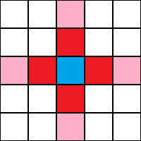

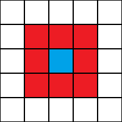

4. **Initial conditions**. The automaton needs to be populated, and the location and number of points that are present (also termed “live”) needs to be determined.
5. **The rules**. The rules determine how points (synonymous with cells) interact with one another.
6. **The boundaries**. The last feature of automata are the boundaries and how to treat cells that are on the edges of the space.

**Question 1.1** Without reading ahead, think about how, if you were going to tell a computer to create a cellular automaton, you would do so. Write *precicely* how you’d do that.

In 1970, mathematician John Conway devised The Game of Life. The game has *only* four simple rules

- Live cells with < 2 neighbors die because the local population is too small
- Live cells with > 3 neighbors die because the local population is too large
- Live cells survive a time step
- Empty cells with 3 neighbors are reproduced into

With these rules, the simulations were able to show complex behaviors. Some of the recurrent congigurations include static states, oscillating states (with varying periodicity), and repetitive states that “move” across the grid. Further, the persistence of the siimulation depends on the initial conditions: how many live cells exist and their location relative to one another.

Below I have written a version of The Game of Life. It is not the most computationally efficient (it can be written much faster) nor condensed, but, I hope, it is the most student/human-readable code.

1.2. I would like for you to have an understanding of how this is fomulated. Please translate the code verbally. That is, I would like for you to determine what is happening “under the hood” for the automaton, and summarize. You don’t need to translate the first line (beginning with `par()`) nor the last 7 lines (beginning with `plot()`).

```r
  par(mfrow = c(6, 6), mar = c(1, 1, 1, 1)
  rec.rows <- 25
  rec.cols <- 25
  timesteps <- 36

  time.seq <- seq(from = 1, to = timesteps)
  n.frames <- length(time.seq)
  total.time = 10

  # `rbindom()` will return `n` values of `size` samples (coin flips) with some `prob`
  rand.vals <- rbinom(n = rec.rows*rec.cols, size = 1, prob = 0.62)
  ca.mat <- matrix(data = rand.vals, nrow = rec.rows, ncol = rec.cols)

  for (times in 1:timesteps){
    for (i in 1:rec.rows) {
      for (j in 1:rec.cols) {
        # Interior rectangle
        if (i != 1 & i != rec.rows & j != 1 & j != rec.cols) {
            N <- ca.mat[i+1, j]
            NE <- ca.mat[i+1, j+1]
            E <- ca.mat[i, j+1]
            SE <- ca.mat[i-1, j+1]
            S <- ca.mat[i-1, j]
            SW <- ca.mat[i-1, j-1]
            W <- ca.mat[i, j-1]
            NW <- ca.mat[i+1, j-1]
        } else {
                # Row 1
            if (i == 1 & j != 1 & i == 1 & j != rec.cols) {
                N <- ca.mat[i+1, j]
                NE <- ca.mat[i+1, j+1]
                E <- ca.mat[i, j+1]
                SE <- ca.mat[rec.rows, j+1]
                S <- ca.mat[rec.rows, j]
                SW <- ca.mat[rec.rows, j-1]
                W <- ca.mat[i, j-1]
                NW <- ca.mat[i+1, j-1]
            }
            # Row rec.rows
                if (i == rec.rows & j != 1 & i == rec.rows & j != rec.cols){
                N <- ca.mat[1, j]
                NE <- ca.mat[1, j+1]
                E <- ca.mat[i, j+1]
                SE <- ca.mat[i-1, j+1]
                S <- ca.mat[i-1, j]
                SW <- ca.mat[i-1, j-1]
                W <- ca.mat[i, j-1]
                NW <- ca.mat[1, j-1]
            }
            # Col 1
            if (j == 1 & i != 1 & j == 1 & i != rec.rows){
                N <- ca.mat[i+1, j]
                NE <- ca.mat[i+1, j+1]
                E <- ca.mat[i, j+1]
                SE <- ca.mat[i-1, j+1]
                S <- ca.mat[i-1, j]
                SW <- ca.mat[i-1, rec.cols]
                W <- ca.mat[i, rec.cols]
                NW <- ca.mat[i+1, rec.cols]
            }
            # Col rec.cols
            if (j == rec.cols & i != 1 & j == rec.cols & i != rec.rows){
                N <- ca.mat[i+1, j]
                NE <- ca.mat[i+1, 1]
                E <- ca.mat[i, 1]
                SE <- ca.mat[i-1, 1]
                S <- ca.mat[i-1, j]
                SW <- ca.mat[i-1, j-1]
                W <- ca.mat[i, j-1]
                NW <- ca.mat[i+1, j-1]
            }
            # Bottom-left corner
            if (i == 1 & j == 1){
                N <- ca.mat[i+1, j]
                NE <- ca.mat[i+1, j+1]
                E <- ca.mat[i, j+1]
                SE <- ca.mat[rec.rows, j+1]
                S <- ca.mat[rec.rows, j]
                SW <- ca.mat[rec.rows, rec.cols]
                W <- ca.mat[i, rec.cols]
                NW <- ca.mat[i+1, rec.cols]
            }
            # Bottom-right corner
            if (i == 1 & j == rec.cols){
                N <- ca.mat[i+1, j]
                NE <- ca.mat[i+1, 1]
                E <- ca.mat[i, 1]
                SE <- ca.mat[rec.rows, 1]
                S <- ca.mat[rec.rows, j]
                SW <- ca.mat[rec.rows, j-1]
                W <- ca.mat[i, j-1]
                NW <- ca.mat[i+1, j-1]
            }
            # Top-right corner
            if (i == rec.rows & j == rec.cols){
                N <- ca.mat[1, j]
                NE <- ca.mat[1, 1]
                E <- ca.mat[i, 1]
                SE <- ca.mat[i-1, 1]
                S <- ca.mat[i-1, j]
                SW <- ca.mat[i-1, j-1]
                W <- ca.mat[i, j-1]
                NW <- ca.mat[1, j-1]
            }
            # Top-left corner
            if (i == rec.rows & j == 1){
                N <- ca.mat[1, j]
                NE <- ca.mat[1, 1]
                E <- ca.mat[i, 1]
                SE <- ca.mat[i-1, 1]
                S <- ca.mat[i-1, j]
                SW <- ca.mat[i-1, j-1]
                W <- ca.mat[i, j-1]
                NW <- ca.mat[1, j-1]
            }
        }
        neigbors.sum <- sum(c(N, NE, E, SE, S, SW, W, NW))

        if (ca.mat[i, j] == 1) {
            if (neigbors.sum < 2 | neigbors.sum > 3) {
              ca.mat[i, j] <- 0
              } else {
            ca.mat[i, j] <- 1
          }
        } else {
            if (neigbors.sum == 3) ca.mat[i, j] <- 1
        }
      } # end of j loop
    } # end of i loop
      plot(x = 0.5:(rec.cols+1), y = 0.5:(rec.rows+1), main = paste0("Time step = ", times), las = 1, xlab = "Columns", ylab = "Rows", xaxs = "i", yaxs = "i", type = "n", xaxt = "n", yaxt = "n")
      cols.vec <- seq(from = 0.5, to = rec.cols+2, by = 1)
      rows.vec <- seq(from = 0.5, to = rec.rows+2, by = 1)
      segments(x0 = cols.vec, y0 = rep(0, length(cols.vec)), x1 = cols.vec, y1 = rep(rec.rows, length(cols.vec)), lwd = 0.5, col = "grey75")
      segments(y0 = cols.vec, x0 = rep(0, length(rows.vec)), y1 = cols.vec, x1 = rep(rec.cols, length(rows.vec)), lwd = 0.5, col = "grey75")
         image(x = 1:rec.cols, y = 1:rec.rows, t(ca.mat), col = c(NA, "grey40"), add = T, xaxs = "i", yaxs = "i", xaxt = "n", yaxt = "n")
    } # end of times loop
```

1.3 Next, copy the code, run it, and include a plot here. Check the squares and see if they are following the 4 rules that we gave them above.

1.4. In the first line, replace `c(6, 6)` in `par()` with `c(1, 1)`. This specifies the number of rows and columns in a plot, so we’ve moved from a 6x6 (for teh 36 simulations) to 1, like you’re used to seeing. Next, create a new line above `plot()` at the end. Write: `png(paste0([your working directory], times, ".png"))` and after the `image()` function, start a new line and add `dev.off()`. This tells R when to start saving a plot as a .png and when to stop. For `[your working directory]`, put where you want your plot output. Mine is in “/home/cmmoore/”. Then, outside of R, open the application “ImageJ”. Go to “File” -> “Import…” -> “Image sequence”, and select your files. Follow the directions to make an animation of how your populations change over time in space! Save the movie to the directory where your Markdown file exists. From there, embed in Markdown (outside of the chunk) the following html but changing the name of your video file (mine is `GOL_1.mp4`):

```html
<video width="600" height="600" controls loop>
  <source src="GOL_1.mp4" type="video/mp4">
</video>
```

To embed your video in Markdown:

[video not shown]

1.4. As of 12:45, we have software that might help us make movies without using ImageJ! At the top of your code, inclue:

```r
saveVideo({
  rec.rows <- 100
  rec.cols <- 100
  timesteps <- 100

  time.seq <- seq(from = 1, to = timesteps)
  n.frames <- length(time.seq)
  total.time = 15
  ani.options(interval = total.time/n.frames, nmax = n.frames)
```

At the end of your code, include

```r
}, video.name = "GOL_mine.mp4", ani.width = 800, ani.height = 800, ani.dev = function(...){png(res=200,...)}
)
```

Let’s see if it works!!!

1.5. Look at your simulation. How many of the patterns do you see from here: [Wikipedia link](https://en.wikipedia.org/wiki/Conway%27s_Game_of_Life#Examples_of_patterns). Which ones did you observe?

Also, for a more sped up, easier version of this population game that you can edit in real time, follow this link: [link](http://pmav.eu/stuff/javascript-game-of-life-v3.1.1/)

1.6. Notice that the initial conditions were set by a probability that a given cell was occupied. Recude the number of inidial inviduals until you reach a “percolation point,” a value over or under which a simulation will not persist, let’s say 1/2 of the times you run it. Let’s define “persist” as 100 timesteps.

1.7. Expand the grid size (rows and columns) at the percolation point. How does that affect the ability for life to persist? Reduce the grid size at the percolation point. How does that affect the ability for life to persist?